# 智能日程助手市场调查报告

### 痛点特征与解决方案接受度

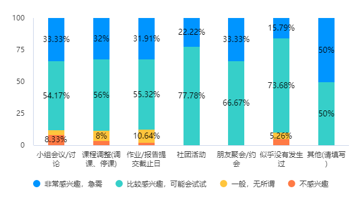

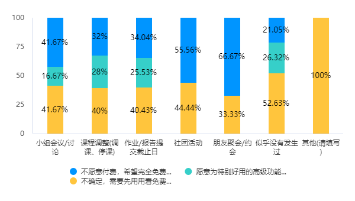

### 功能偏好与付费意愿

不同产品概念偏好与月度订阅价格接受度的关联，呈现出明显的定位差异。偏好 “一款能自动从微信聊天里提取日程的工具” 这一概念的用户，对各价格区间的接受度相对分散，5 元及以下、6-10 元、11-15 元的占比均为 22.22%，16-20 元的占比稍高（33.33%），未表现出明确的集中倾向；而偏好 “一款永不你错过任何群消息重要日程，并提供智能提醒” 概念的用户，价格接受度则更聚焦于 11-15 元区间，占比达到 41.67%，5 元及以下的占比为 25%，其余区间占比相对均衡 —— 这意味着强调 “不遗漏 + 智能提醒” 的概念用户，对中价位的接受度更高，而侧重 “自动提取效率” 的概念用户，价格敏感度的分布更分散。

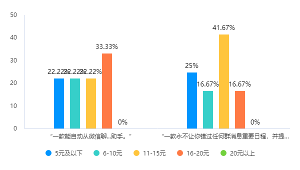

智能功能偏好与付费意愿的关联，则进一步体现出功能类型对用户付费倾向的影响。对于 “冲突检测”“智能时间建议” 等核心实用功能，用户的付费意愿普遍处于中等水平：“不愿付费，希望完全免费” 的占比在 27%-35% 之间，“愿意为特别好用的高级功能付费” 的占比在 17%-25% 之间，多数用户选择 “不确定，需要先用用看免费版”（占比 40%-48%），反映出核心功能用户更依赖免费体验来验证价值；“习惯学习” 功能的付费意愿相对均衡，不愿付费与愿意付费的占比均为 28.57%，不确定的占比为 42.86%；“每周复盘” 这类延伸功能的用户中，“不确定” 的占比高达 61.54%，不愿付费的占比仅 15.38%，观望情绪更为突出；而选择 “以上都不需要” 智能功能的用户，100% 倾向 “不确定”，几乎没有明确的付费或拒绝倾向。

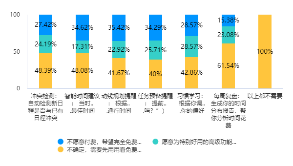

整体来看，核心智能功能的偏好用户以 “观望式付费态度” 为主，免费体验是撬动其付费意愿的关键前提；延伸类功能的用户观望情绪更浓，对功能价值的感知尚未形成明确认知；而不同产品概念用户的价格接受区间差异，也为后续结合概念定位制定差异化定价策略提供了具体的参考方向。

## 开放题文本分析

### “您最喜欢这个概念哪一点？” 文本分析

用户对该智能日程助手概念的偏好，集中体现为 **“便捷性、提醒功能、贴心体验” 三大核心诉求的匹配 **。其中 “便捷性” 是最突出的偏好点，“不需要手动切换软件”“自动整理繁琐导入”“微信内更方便” 等表述高频出现，精准命中了用户当前日程管理中 “跨工具操作低效、手动录入繁琐” 的痛点，微信生态内的集成模式进一步强化了这一便捷性感知。

“提醒功能” 是第二大偏好方向，“不错过重要日程”“预备提醒” 等反馈，与前期痛点分析中 “遗忘群聊日程” 的高频场景形成呼应，体现出用户对 “避免信息遗漏” 的核心需求被满足。而 “贴心体验” 的偏好也较为明显，“小管家更贴心”“帮规划时间好贴心” 等表述，说明 “情感化、辅助式” 的产品定位更易获得用户好感；同时有用户明确提及 “提取聊天记录会有隐私担忧”，侧面印证了 “贴心小管家” 的概念在缓解隐私顾虑上的优势。

此外，少量用户提到 “解决市场软件空缺”“提高办事效率”，体现出对工具实用价值与市场定位的认可，进一步强化了该概念与用户需求的匹配度。

### “对于你理想中的‘智能日程助手’，你还有任何其他的期望、想法或担忧吗？” 文本分析

用户的反馈可分为功能期望、功能 / 体验担忧、操作顾虑三类，清晰指向工具优化的核心方向。功能期望上，“课表录入”“朋友共享日程” 的需求，是对学生群体核心日程场景（课表）与社交协作场景的延伸，体现出用户对工具 “覆盖更多高频场景” 的期待。

功能与体验担忧是反馈的重点：一方面是 “模糊信息识别”“日程导入准确性” 的功能精准度问题，与前期 “识别不准确” 的痛点顾虑一致，说明用户对工具核心功能的可靠性有较高要求；另一方面是 “页面卡顿”“摇一摇广告” 的体验问题，反映出用户对工具 “流畅、无干扰” 的基础使用诉求。

操作顾虑则集中在 “额外打卡繁琐”“使用习惯难改变”，部分用户表示 “现有 app 用得顺手、智能工具需求不强”，说明工具的操作门槛与用户既有习惯的冲突，可能成为用户转化的关键阻碍。

用户对智能日程助手的期望聚焦于场景延伸与功能精准，而担忧则围绕核心功能可靠性、使用体验与操作适配性，这些反馈为工具的功能迭代与体验优化提供了直接的落地方向。

# 竞品分析

## 操作系统原生日历工具

操作系统原生日历工具（如iOS日历、华为日历）构成了市场的基础层。 它们作为设备的基础设施，拥有系统级集成的天然优势，如最高的通知权限和无需下载的便捷性。然而，其核心劣势在于彻底的“被动性”与“场景孤立性”。它们是与用户信息流入端（尤其是微信这样的社交沟通主阵地）完全割裂的“信息孤岛”。用户必须主动将已在聊天信息中明确的事项，手动输入或复制粘贴到日历中，这个过程不仅造成了不必要的操作负担，更关键的是引入了遗忘和出错的巨大风险。从用户差评中我们频繁看到“懒得每次手动输入”、“经常忘记从群里转到日历”等真实反馈，这恰恰印证了原生工具在“信息输入”这一起始环节存在巨大体验鸿沟。因此，WeSchedule的突破口并非笨拙地试图替代原生日历，而是策略性地定位为赋能原生日历的“智能化桥梁”。我们的价值在于填补从“信息产生”到“信息记录”之间的自动化空白，通过一键转发完成信息解析与录入，让用户继续在他们熟悉且信任的原生日历中进行查看和管理，这一定位巧妙地规避了与系统级应用的正面竞争，转而成为其不可或缺的互补性服务。

## 第三方专业效率应用

第三方专业效率应用（如滴答清单、Todoist）代表了功能深度与方法论导向的解决方案。 这类产品功能强大，深受资深效率爱好者的青睐，支持GTD等多种时间管理方法论，跨平台同步体验完善。但其成功的关键，也构成了其在大学生市场中普及的障碍：过于“重型”与“复杂”。对于绝大多数追求轻快、便捷的大学生而言，这些应用庞杂的功能体系带来了显著的学习成本和认知负担。应用商店的用户差评中，“功能太复杂不知道从何用起”、“设置繁琐”等声音不绝于耳。更重要的是，它们与操作系统原生工具一样，同样与微信场景相分离，未能解决信息从聊天窗口到任务列表的“无缝流转”这一根本性痛点。它们试图为用户建造一个功能齐备的“效率堡垒”，但大学生需要的或许只是一座能够轻松跨越信息鸿沟的“便捷桥梁”。WeSchedule的差异化定位正在于此——我们不做大而全的“瑞士军刀”，而是极致聚焦于“微信消息转日程”这一单点痛点，追求极致的简单和流畅。我们深刻理解大学生群体“够用就好”的核心诉求，以单一功能解决最高频的场景问题，这种极简主义恰恰是对抗功能泛滥的最佳策略。

## 超级App的内置功能

超级App的内置功能（如微信收藏备注、钉钉/飞书日程）则代表了生态内的潜在竞争。 它们虽身处生态内部，避免了场景切换的成本，但其发展往往受限于母体应用的战略重心。以微信为例，其“收藏”功能中的笔记备注虽可简单记录日程，但体验隐蔽、功能薄弱，更像一个临时备忘录，而非一个真正的日程管理工具。钉钉、飞书的日程功能则深深打上了职场协同的烙印，其正式、严谨的风格与大学生相对轻松、个性化的社交学习氛围存在隔阂。这些内置功能的用户差评多集中于“不好用”、“太难找”、“提醒不强”等。这揭示了一个关键的市场空白：在国民级应用微信的生态内，存在着一个“功能洼地”——日程管理需求真实且强烈，但平台自身提供的解决方案体验远未达标。这为WeSchedule这样的垂直、专注的小程序提供了绝佳的生存土壤。我们的定位是成为“微信生态中最懂日程的专家”，而非一个什么都能做但什么都不精的通才。我们通过深度集成微信的分享接口，提供远超微信内置功能的专业日程管理体验，填补这一生态位空白。

综合而言，对竞争格局的深度分析清晰地指向了WeSchedule的差异化定位与独特机会。 我们的战略不是与任何一层级的对手进行同质化功能的军备竞赛，而是精准切入“大学生”、“微信生态”、“日程信息自动化”这三个关键词的交汇点。我们敏锐地洞察到，现有解决方案无论是系统级工具、专业应用还是生态内功能，都无法很好地解决“信息从碎片化沟通场景到结构化日历的低成本、高可靠流转”这一核心问题。用户差评中弥漫的“麻烦”、“复杂”、“易忘”情绪，正是市场向我们发出的最强烈信号。因此，WeSchedule的立身之本是场景的深度而非功能的广度。我们通过“手动转发”这一在控制感与便捷性之间取得精妙平衡的交互方式，打造一种“沟通即记录”的无缝体验。这一看似细微的创新，实则是针对一个巨大且被忽视的用户痛点的精准手术刀式打击，有望在巨头林立的效率工具市场中，开辟出一个属于我们自己的、极具用户粘性的价值空间。

# 需求验证结论与商业可行性分析

## 需求验证核心结论

调研数据充分验证了 WeSchedule 产品概念的合理性与必要性，核心结论如下：其一，用户痛点真实且普遍，PRD 提出的 “信息过载与遗漏风险、操作割裂效率低、工具被动缺乏智能” 三大痛点均得到数据支撑，80% 的用户有过遗漏群聊日程的经历，45.6% 的用户 “经常 / 总是” 觉得手动录入繁琐，超 50% 的用户期待冲突检测、智能时间建议等智能功能，学业场景（作业 / 报告提交截止日占比 52.22%）是核心痛点场景；其二，解决方案接受度显著，针对 “微信消息转日程” 的核心功能，29.9% 的用户 “非常感兴趣，急需”，57.5% 的用户 “比较感兴趣，可能会试试”，合计近 88% 的接受度，且日均群聊 15 个以上、高活跃用户的 “非常感兴趣” 占比更高，印证了解决方案与核心用户需求的高度契合；其三，用户顾虑聚焦明确，“识别不准确，经常出错”（平均得分 4.08）、“提醒不及时或过度提醒”（平均得分 3.96）、“操作体验差，小程序卡顿”（平均得分 3.93）是用户最核心的三大顾虑，隐私安全与收费模式顾虑相对次要，但仍需重视；其四，种子用户画像清晰，大二至大四的社团达人 / 学生干部、科研党 / 研究生、实习兼职活跃者三类群体，具备日程密集、群聊参与度高、痛点显著、付费意愿较强的特征，是产品初期的核心目标用户。

## 商业可行性分析

从市场、付费、成本、竞争四大维度分析，WeSchedule 具备明确的商业可行性：其一，市场机会稀缺且规模可观，微信生态内缺乏聚焦大学生群体的轻量日程管理工具，现有工具或与微信场景割裂，或功能过重，而中国大学生群体规模庞大，数字化接受度高，微信使用粘性强，核心痛点未被满足，市场空白明确；其二，付费模式具备可持续性，调研显示 24.1% 的用户明确愿意为高级功能付费，44.8% 的用户持观望态度（需免费版体验验证价值），愿意付费用户的月度价格接受区间集中在 5-15 元（11-15 元占比 33.3%），与大学生 “一杯奶茶钱” 的消费心理账户匹配，免费增值（基础功能免费 + 高级智能功能付费）的模式既能快速积累用户，又能实现商业变现；其三，成本结构可控，MVP 阶段以微信小程序为载体，开发与迭代成本低于独立 App，初期用户激励金（约 6000 元）、问卷平台与分析工具会员等成本可承受，后续规模化阶段的服务器与 API 调用成本可随用户增长逐步分摊；其四，竞争壁垒可逐步构建，产品的核心壁垒在于微信生态的深度集成（“转发” 交互无缝衔接沟通场景）、校园场景的精准适配（课程表导入、地点库匹配）、用户行为数据积累带来的 AI 识别准确率提升，这些壁垒难以被传统效率工具或微信内置功能快速复制，同时隐私合规、技术准确性等风险可通过明确隐私政策、优化 NLP 引擎、设计友好编辑界面等方式有效应对。

# 战略建议与行动方案

## 核心战略建议

产品层面，坚持 “极简核心、快速验证、迭代优化” 的战略，MVP 阶段聚焦 “微信消息转日程” 的核心流程，不堆砌功能，优先解决用户核心顾虑，后续基于用户数据逐步迭代智能功能；市场层面，采取 “精准触达、口碑裂变、场景渗透” 的策略，聚焦高活跃核心用户群体，通过校园场景化推广建立初始用户池；运营层面，以 “免费拉新、体验转化、口碑留存” 为核心，通过免费版核心功能吸引用户，借助优质体验促进付费转化，依托用户反馈快速优化产品。

## 具体行动方案

产品行动上，严格围绕 “新体验 - 旧体验 - 转换成本 = 用户价值” 的思维打造 MVP：首先，聚焦 “转发 - 解析 - 确认 - 同步至原生日历” 的全链路极简体验，新体验的核心是将旧体验中 “切换 App + 手动输入 + 反复核对” 的 4-6 步繁琐流程，简化为 “一键转发 + 确认” 的 2 步操作，同时降低转换成本 —— 无需用户下载安装（微信小程序直接触达）、无需学习新操作（沿用微信转发习惯）、无需放弃现有工具（同步至用户熟悉的原生日历），让用户以极低成本获得便捷体验；其次，针对用户最顾虑的 “识别不准确” 问题，MVP 阶段接入大语言模型 API 并结合校园场景语料（课程名、地点名、常用时间表述）优化 NLP 引擎，将识别准确率提升至 75% 以上，同时设计简洁直观的预览编辑界面，允许用户快速修正错误，降低 “修正成本”，相比旧体验中 “手动输入易出错且难修改” 的痛点形成显著优势；最后，优化提醒机制，提供 “默认提醒 + 自定义提醒” 选项，支持用户设置不同场景的提前提醒时间（如作业截止日提前 1 天、会议提前 30 分钟），解决 “提醒不及时或过度提醒” 的顾虑，让新体验的 “贴心提醒” 超越旧体验中 “无针对性提醒” 的被动状态。

市场行动上，精准触达核心用户以降低获客成本与信任转换成本：优先在西安交通大学试点，通过学生会、社团、项目小组等高活跃用户集中的社群，开展 “种子用户招募计划”，提供 1 个月免费会员激励，让核心用户率先体验产品价值，借助其在校园内的社交影响力实现口碑裂变；与校园 KOL（如学生组织负责人、效率类博主）合作，通过真实使用场景的短视频、图文内容种草，突出 “转发即创建日程” 的便捷性，对比旧体验的繁琐，强化用户对产品价值的感知；在教学楼、图书馆、社团活动场地等场景设置线下推广点，提供扫码即体验的便捷入口，现场指导用户完成首次 “转发 - 创建日程” 操作，降低用户的初始使用转换成本。

运营行动上，通过全链路运营提升用户价值与付费转化：上线初期，免费版开放 “消息转日程” 核心功能与基础的日程列表查看功能，满足用户核心需求，同时通过弹窗引导用户反馈使用问题（如识别错误、操作不便），既收集优化数据，又增强用户参与感；针对免费版用户，当累计创建 10 条以上日程后，推送 “7 天高级功能体验卡”（含冲突检测、动线规划提醒），让用户直观感受高级功能的价值，降低付费决策的转换成本 —— 新体验的 “智能规划” 相比旧体验的 “单纯记录” 与免费版的 “基础创建” 形成差异，同时将月度会员价格定为 12 元（契合 5-15 元的核心接受区间），并提供 “首月半价 6 元” 的优惠，进一步降低付费门槛；建立用户反馈社群，快速响应并解决用户的使用问题，针对高频反馈的识别错误案例，每周更新 NLP 识别规则库，让产品体验持续优化，同时通过社群收集用户对新功能的需求，形成 “用户反馈 - 产品优化 - 价值提升” 的正向循环，不断扩大新体验与旧体验的差距，提升用户留存与付费意愿。

# AI使用情况报告

主要使用模型：Deepseek，Kimi，Doubao

主要使用情况：制图代码编写；图表的说明与分析；文献查找；分析思路参考；文本撰写，包括依据提纲扩写、修改优化内容、总结性文字撰写等。

# 参考文献

略

# 附录A 调研问卷

**关于大学生日程管理需求与AI工具接受度的调研**

同学你好！这是一份关于日程管理习惯与需求的匿名调查，旨在帮助大学生更轻松地应对微信群聊中的日程信息，告别遗忘和手动输入的烦恼，耗时约2-3分钟。你的每一个反馈都至关重要，感谢你的宝贵时间！

你是否是中国内地高校在校大学生? [单选题] *

| ○是 |
| --- |
| ○否 |

你的年级是? [单选题] *

| ○大一 |
| --- |
| ○大二 |
| ○大三 |
| ○大四 |
| ○研究生及以上 |

你的专业类型是? [单选题] *

| ○理工类 |
| --- |
| ○人文社科类 |
| ○经管类 |
| ○艺术体育类 |
| ○医学类 |
| ○其他 _________________ |

你目前担任的职务或参与的活动类型是? [多选题] *

| □学生会/团委干部 |
| --- |
| □社团骨干或活跃成员 |
| □项目小组组长或负责人 |
| □班级干部(班长、学委等) |
| □实习兼职 |
| □以上均无 |

你平均每天使用微信的时长是? [单选题] *

| ○1小时以下 |
| --- |
| ○1-3小时 |
| ○3-5小时 |
| ○5小时以上 |

你平均每日参与的群聊数量(包括课程群、小组群、社团群等)是? [单选题] *

| ○5个以下 |
| --- |
| ○5-10个 |
| ○10-15个 |
| ○15个以上 |

你目前主要使用什么工具来管理你的课程表、会议、任务截止日等日程? [多选题] *

| □手机系统自带的日历(如iOS日历、华为日历) |
| --- |
| □纸质笔记本/手账 |
| □第三方日历App(如Google Calendar) |
| □待办清单App(如滴答清单、Todoist) |
| □微信/QQ的聊天记录、收藏或备注功能 |
| □靠脑子记 |
| □其他(请填写) _________________ |
| □我几乎不系统管理日程 |

你对你当前主要使用的日程管理工具，总体满意度如何? [单选题] *

| ○非常不满意 | ○不满意 | ○一般 | ○满意 | ○非常满意 |
| --- | --- | --- | --- | --- |

依赖于（题目：你目前主要使用什么工具来管理你的课程表、...）第1;2;3;4;5;7个选项

在微信群聊中讨论并产生日程安排时，你遇到以下情况的频率如何?[矩阵单选题] *

|  | 总是 | 经常 | 有时 | 很少 | 从不 |
| --- | --- | --- | --- | --- | --- |
| 担心自己会忘记看群消息/忘了记下来 | ○ | ○ | ○ | ○ | ○ |
| 手动从聊天框切换到日历 App输入很麻烦 | ○ | ○ | ○ | ○ | ○ |
| 事后找不到那条消息了 | ○ | ○ | ○ | ○ | ○ |
| 记下了时间，但忘记了需要提前准备(如准备材料) | ○ | ○ | ○ | ○ | ○ |
| 记下了会议时间，但低估了通勤时间导致迟到 | ○ | ○ | ○ | ○ | ○ |

最近一次因为遗漏或忘记群聊中的日程信息而带来不便，是在什么场景下? [多选题] *

| □小组会议/讨论 |
| --- |
| □课程调整(调课、停课) |
| □作业/报告提交截止日 |
| □社团活动 |
| □朋友聚会/约会 |
| □似乎没有发生过 |
| □其他(请填写) _________________ |

如果有一款微信小程序，能让你只需将微信聊天消息“转发”给它，它就自动识别出里面的时间、事件、地点并为你一键生成日历日程，你对这个功能的感兴趣程度是? [单选题] *

| ○非常感兴趣，急需 |
| --- |
| ○比较感兴趣，可能会试试 |
| ○一般，无所谓 |
| ○不感兴趣 |

你对这个核心功能不感兴趣的主要原因是? [多选题] *

| □现有的方式已足够，没有痛点 |
| --- |
| □不信任AI的识别准确性 |
| □担心隐私和安全问题 |
| □"转发"这个操作依然麻烦 |
| □更希望有全自动的方案(无需手动转发) |
| □其他(请填写) |

依赖于（题目：如果有一款微信小程序，能让你只需将微信聊...）第4个选项

除了“转发消息”，你认为哪种方式对你来说也更自然便捷？ [多选题] *

| □复制文字后，打开小程序能自动识别并提示粘贴 |
| --- |
| □在微信内长按文字时，菜单中出现“添加到[产品名]”的选项 |
| □通过Siri/语音助手直接说“把这件事加到我的日程” |
| □其他 _________________ |

以下哪些智能功能让你觉得这款工具更有吸引力？（请选择您认为最重要的1-3项) [多选题] *

| □冲突检测： 自动检测新日程是否与已有日程冲突 |
| --- |
| □智能时间建议： 当时间模糊时（如“下周五下午”），自动推荐一个不会与你课程冲突的最佳时间 |
| □动线规划提醒： 根据课程/会议地点，提前提醒你“该出发了”，并估算通行时间 |
| □任务预备提醒： 提前提醒你为会议或任务做准备（如“明天要开会，今晚需要准备材料吗？”） |
| □习惯学习： 根据你调整日程的习惯（如总提前15分钟），自动学习并应用你的偏好 |
| □每周复盘： 生成你的时间分布报告，帮你分析时间花费 |
| □以上都不需要 |

如果这款产品基础功能(解析消息、创建日程)免费，高级的智能功能需要订阅付费，你的态度是? [单选题] *

| ○不愿意付费，希望完全免费(即使这意味着没有高级功能) |
| --- |
| ○愿意为特别好用的高级功能付费 |
| ○不确定，需要先用用看免费版再决定 |

请根据您的第一感觉，选择更偏好的概念 [单选题] *

| ○“一款能自动从微信聊天里提取日程、并为你智能规划最佳时间安排的AI助手。” |
| --- |
| ○“一款永不让你错过任何群消息重要日程，并提供贴心预备提醒的智能小管家。” |

您最喜欢这个概念哪一点? [填空题]

_________________________________

根据以上描述，您的购买兴趣有多大？(1-5分，1分=完全没兴趣，5分=非常有兴趣)

[单选题] *

| ○1 |
| --- |
| ○2 |
| ○3 |
| ○4 |
| ○5 |

你愿意接受的月度订阅价格范围是? [单选题] *

| ○5元及以下 |
| --- |
| ○6-10元 |
| ○11-15元 |
| ○16-20元 |
| ○20元以上 |

依赖于（题目：如果这款产品基础功能(解析消息、创建日程...）第2个选项

如果付费，哪些因素最能说服你开通会员?请选择最重要的2项。 [多选题] *

| □能显著提升我的学习/工作效率 |
| --- |
| □能彻底解决我遗忘日程的焦虑感 |
| □功能独特，其他产品无法替代 |
| □价格非常便宜，一杯奶茶的钱 |
| □同学/朋友都在用，且口碑很好 |
| □其他(请填写) |

你对尝试这样一款工具的顾虑是什么?*（1=完全不担心，5=非常担心）*[矩阵量表题] *

|  | 1 | 2 | 3 | 4 | 5 |
| --- | --- | --- | --- | --- | --- |
| 隐私安全，担心聊天记录被泄露或滥用 | ○ | ○ | ○ | ○ | ○ |
| 识别不准确，经常出错，反而需要花更多时间修改 | ○ | ○ | ○ | ○ | ○ |
| 操作体验差，小程序卡顿，不如手动输入快 | ○ | ○ | ○ | ○ | ○ |
| 提醒不及时或过度提醒，造成打扰 | ○ | ○ | ○ | ○ | ○ |
| 收费模式，担心后期乱收费或免费版无法使用 | ○ | ○ | ○ | ○ | ○ |

如果这款产品体验良好，你有多大可能将它推荐给身边的同学或朋友? [单选题] *(0代表“完全不可能”，10代表“极有可能”)

| ○0 | ○1 | ○2 | ○3 | ○4 | ○5 | ○6 | ○7 | ○8 | ○9 | ○10 |
| --- | --- | --- | --- | --- | --- | --- | --- | --- | --- | --- |

对于你理想中的“智能日程助手”，你还有任何其他的期望、想法或担忧吗?请自由告诉我们。 [填空题]

_________________________________

问卷结束，再次感谢您的支持！您的反馈对我们至关重要。

# 附录B制图代码

略

# 附录C交叉分析图表

1. 交叉分析：活跃度 × 顾虑

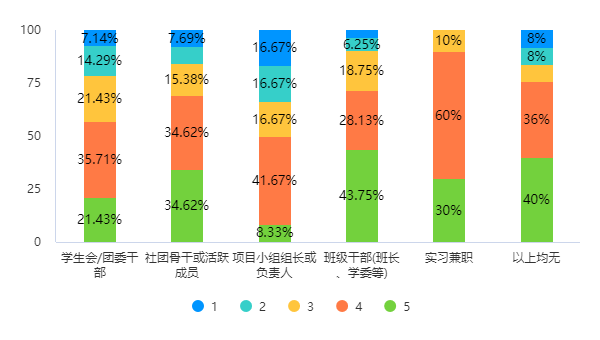

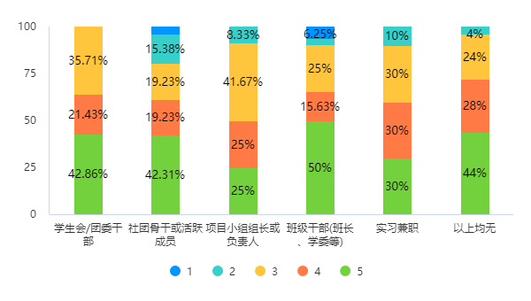

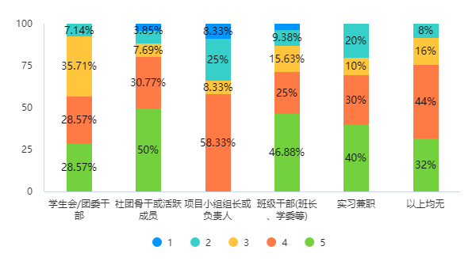

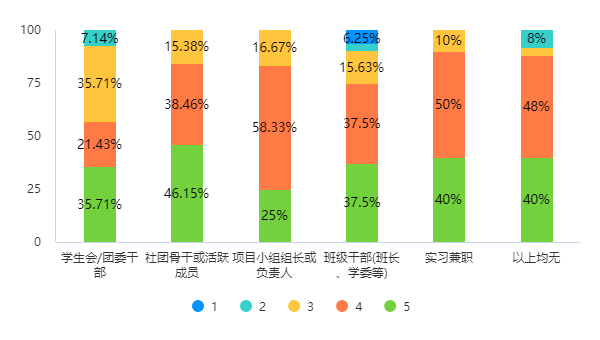

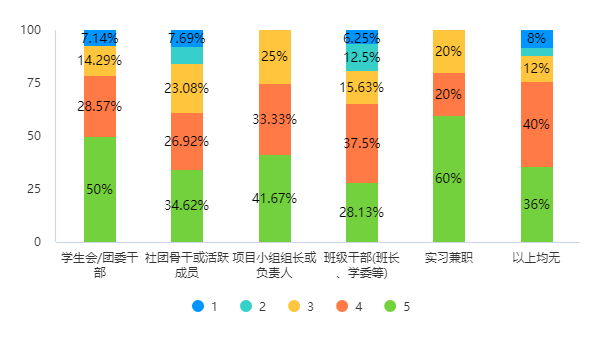

2. 交叉分析：年级 × 顾虑

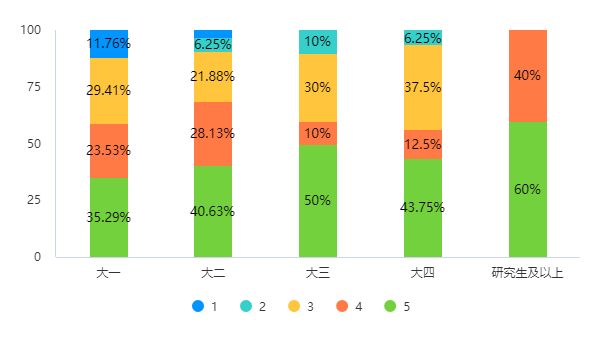

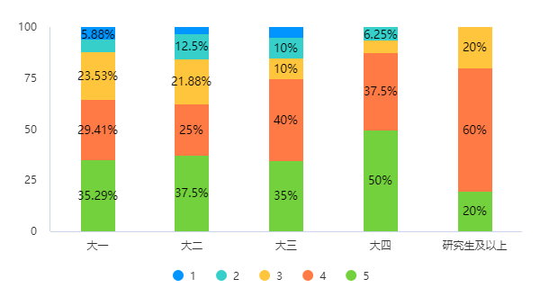

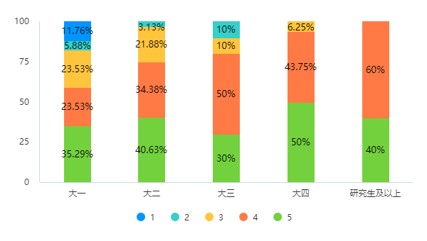

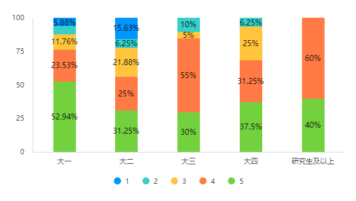

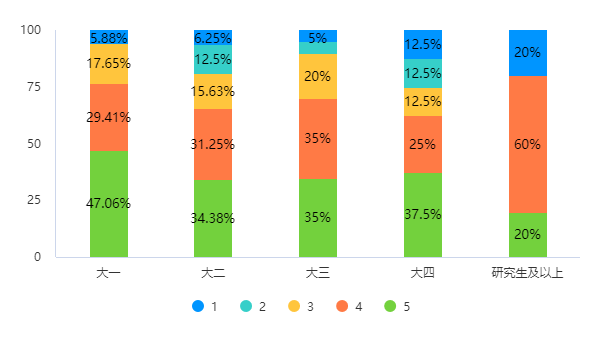

3. 交叉分析：日均群聊数（15 个以上 5 个以下）× 痛点频率

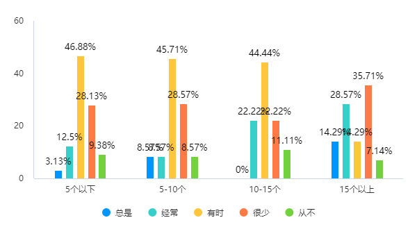

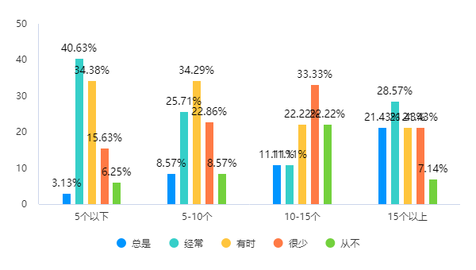

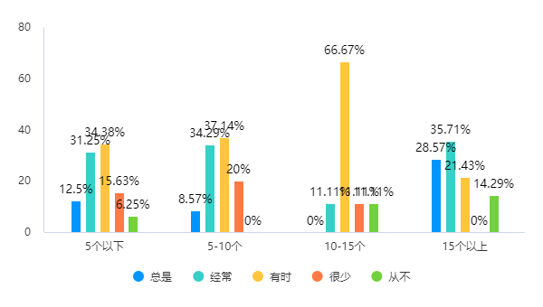

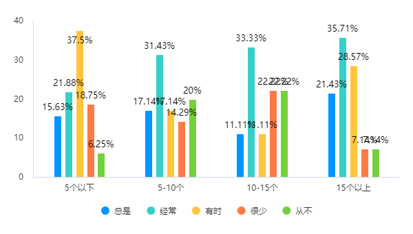

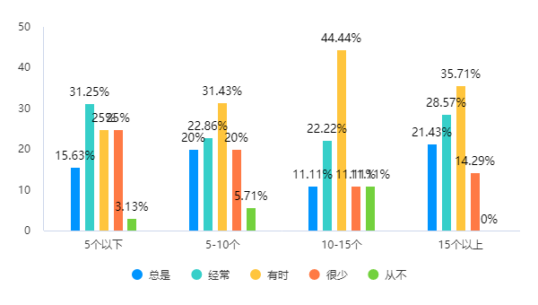

4. 交叉分析：活跃度与痛点频率

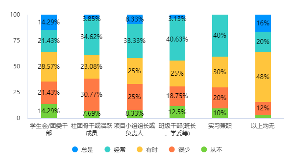

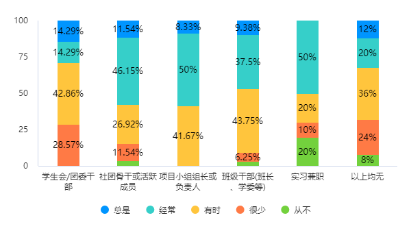

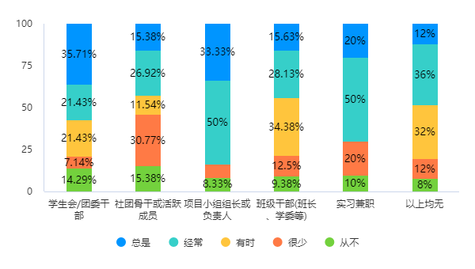

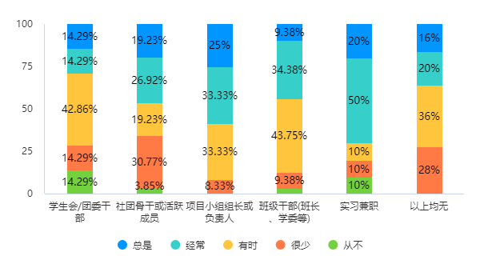

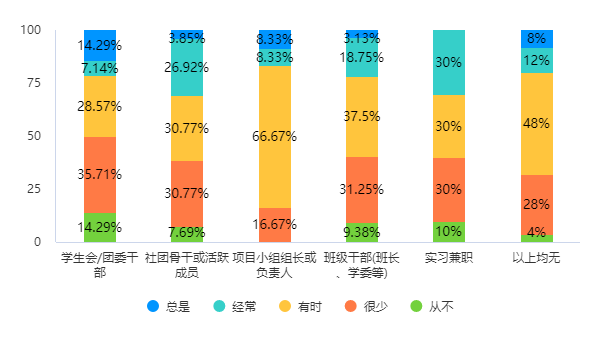